# Tutorial 4B - Feature Transformation

## Week 4 : Feature Transformation

`Feature Transformation` technique implies that the original features are transformed into new direction. There are 3 ways to do this:

1. `Projection`: The existing features are re-oriented on new, better axes. Ex: PCA, LDA etc. This technique works best with linear data.
2. `Manifold Learning`: Used to work on non-linear data. The data is unrolled so that twists and turns are smoothened out. Ex: Spectral Embedding, Isomap etc.
3. `Autoencoding`: Uses neural networks to simplify data.

In this tutorial, we will focus on `Principal Components Analysis`, a Projection technique.

#### When to opt for Feature transformation using PCA?

- Large number of X-variables and most of the features are meaningful.
- The features are highly correlated with each other

#### Import Packages

```python
import pandas as pd
import numpy as np
from sklearn import datasets
import matplotlib.pyplot as plt
from sklearn.metrics import accuracy_score
from sklearn.preprocessing import StandardScaler
from sklearn.model_selection import train_test_split

from sklearn.neighbors import KNeighborsClassifier
from sklearn.decomposition import PCA
```

### Part A: Eigen decomposition in python

A demonstration of: $\textbf{X}v = \lambda v$ for the first principal eigenvalue of the example in lecture 'Dimensionality Reduction'.

```python
X = np.array([[1, 0.5, 0.333, 0.25],
              [0.5, 1, 0.667, 0.5],
              [0.333, 0.667,1, 0.75],
              [0.25, 0.5, 0.75, 1]
             ])
eVal, eVec = np.linalg.eig(X)

print('\neVal: ', eVal)
print('\neVec: ', eVec)

vec1 = eVec[:,0] ; val1 = eVal[0]

print('\nval1: ', val1)
print('\nvec1: ', vec1)

print('\nDot product of X and vec1: ', X.dot(vec1))
print('\nval1 * vec1: ', val1 * vec1)
```

```
eVal:  [2.53622028 0.84835416 0.40787166 0.2075539 ]

eVec:  [[-0.37772731 -0.81062274 -0.44192197 -0.07012723]
 [-0.53227622 -0.18760462  0.74150209  0.36285148]
 [-0.56137693  0.30107833  0.04962821 -0.76924952]
 [-0.50878291  0.46588317 -0.50241086  0.52122562]]

val1:  2.536220279964706

vec1:  [-0.37772731 -0.53227622 -0.56137693 -0.50878291]

Dot product of X and vec1:  [-0.95799966 -1.34996974 -1.42377554 -1.29038555]

val1 * vec1:  [-0.95799966 -1.34996974 -1.42377554 -1.29038555]
```

### Part B: Principal Component Analysis

```python
iris = datasets.load_iris(as_frame=True)
print(iris.DESCR)
```

```
.. _iris_dataset:

Iris plants dataset
--------------------

**Data Set Characteristics:**

    :Number of Instances: 150 (50 in each of three classes)
    :Number of Attributes: 4 numeric, predictive attributes and the class
    :Attribute Information:
        - sepal length in cm
        - sepal width in cm
        - petal length in cm
        - petal width in cm
        - class:
                - Iris-Setosa
                - Iris-Versicolour
                - Iris-Virginica

    :Summary Statistics:

    ============== ==== ==== ======= ===== ====================
                    Min  Max   Mean    SD   Class Correlation
    ============== ==== ==== ======= ===== ====================
    sepal length:   4.3  7.9   5.84   0.83    0.7826
    sepal width:    2.0  4.4   3.05   0.43   -0.4194
    petal length:   1.0  6.9   3.76   1.76    0.9490  (high!)
    petal width:    0.1  2.5   1.20   0.76    0.9565  (high!)
    ============== ==== ==== ======= ===== ====================

    :Missing Attribute Values: None
    :Class Distribution: 33.3% for each of 3 classes.
    :Creator: R.A. Fisher
    :Donor: Michael Marshall (MARSHALL%PLU@io.arc.nasa.gov)
    :Date: July, 1988

The famous Iris database, first used by Sir R.A. Fisher. The dataset is taken
from Fisher's paper. Note that it's the same as in R, but not as in the UCI
Machine Learning Repository, which has two wrong data points.

```

[output cut: 8 more lines]

```

   - Fisher, R.A. "The use of multiple measurements in taxonomic problems"
     Annual Eugenics, 7, Part II, 179-188 (1936); also in "Contributions to
     Mathematical Statistics" (John Wiley, NY, 1950).
   - Duda, R.O., & Hart, P.E. (1973) Pattern Classification and Scene Analysis.
     (Q327.D83) John Wiley & Sons.  ISBN 0-471-22361-1.  See page 218.
   - Dasarathy, B.V. (1980) "Nosing Around the Neighborhood: A New System
     Structure and Classification Rule for Recognition in Partially Exposed
     Environments".  IEEE Transactions on Pattern Analysis and Machine
     Intelligence, Vol. PAMI-2, No. 1, 67-71.
   - Gates, G.W. (1972) "The Reduced Nearest Neighbor Rule".  IEEE Transactions
     on Information Theory, May 1972, 431-433.
   - See also: 1988 MLC Proceedings, 54-64.  Cheeseman et al"s AUTOCLASS II
     conceptual clustering system finds 3 classes in the data.
   - Many, many more ...
```

```python
X = iris.data
X.head()
```

|  | sepal length (cm) | sepal width (cm) | petal length (cm) | petal width (cm) |
| --- | --- | --- | --- | --- |
| 0 | 5.1 | 3.5 | 1.4 | 0.2 |
| 1 | 4.9 | 3.0 | 1.4 | 0.2 |
| 2 | 4.7 | 3.2 | 1.3 | 0.2 |
| 3 | 4.6 | 3.1 | 1.5 | 0.2 |
| 4 | 5.0 | 3.6 | 1.4 | 0.2 |

```python
y = iris.target
```

```python
X_train, X_test, y_train, y_test = train_test_split(X, y, random_state=1)
```

```python
#Normalize the input features
scaler = StandardScaler()
X_train_scaled = scaler.fit_transform(X_train)
X_test_scaled = scaler.transform(X_test)

pca = PCA(n_components=4)
X_train_transformed = pca.fit(X_train_scaled).transform(X_train_scaled)
X_test_transformed = pca.transform(X_test_scaled)

# Proportion of variance explained for each components
print("Variance explained by each of the principal components: ", pca.explained_variance_ratio_)
```

```
Variance explained by each of the principal components:  [0.72668059 0.22951735 0.03949049 0.00431157]
```

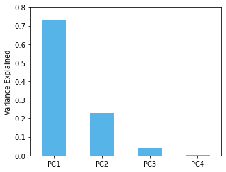

```python
df = pd.DataFrame(pca.explained_variance_ratio_,
                  index=['PC1','PC2','PC3','PC4'],columns =['var'])

plot = df.plot.bar(figsize=(5,4), color='#56B4E9', rot=0)
plot.set_ylabel("Variance Explained")
plot.set_ylim([0,0.8])
plot.get_legend().remove();
```

```python
sum(pca.explained_variance_ratio_)
```

```
1.0000000000000002
```

**Note:** When the number of principal components are equal to the number of features, the variance explained by all the principal components approximately equals 1.

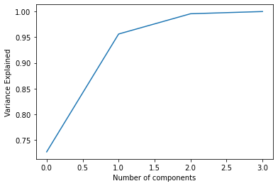

```python
plot = plt.plot(np.cumsum(pca.explained_variance_ratio_, ))
plt.ylabel("Variance Explained")
plt.xlabel("Number of components");
```

The first 3 PC capture ~99% of the variance explained by the data

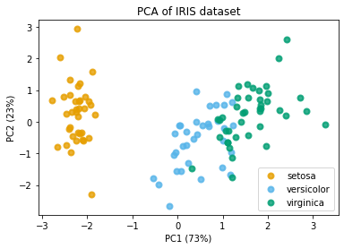

```python
plt.figure()
colors = ['#E69F00', '#56B4E9', '#009E73']
lw = 2

for color, i, target_name in zip(colors, [0, 1, 2], iris.target_names):
    plt.scatter(X_train_transformed[y_train == i, 0],
                X_train_transformed[y_train == i, 1], color=color, alpha=.8, lw=lw,
                label=target_name)
plt.legend(loc='best', shadow=False, scatterpoints=1)
plt.xlabel('PC1 (73%)')
plt.ylabel('PC2 (23%)')
plt.title('PCA of IRIS dataset')

plt.show()
```

PC1 captures ~73% of the variance in iris features while PC2 captures 23% of the variation.

```python
knn_model = KNeighborsClassifier()


knn_model.fit(X_train_transformed, y_train)
y_predicted = knn_model.predict(X_test_transformed)
accuracy_score(y_predicted, y_test)
```

```
0.9736842105263158
```

#### Exercise:

1. Load the wine dataset. Perform PCA. How much of the variance is explained by the first 3 principal components?
2. What is the accuracy of the KNeighborsClassifier on the transformed data? How does it compare to the accuracy obtained through feature selection?